# Hoofprint

Hoofprint: New York Agricultural Land Use

Industrial animal agriculture plays a significant role in shaping land use in New York State.

While forests, conserved lands, and urban centers often dominate public understanding of American landscapes, a substantial share of New York’s actively managed land is tied to agricultural production.

The land is particularly dedicated to livestock feed and grazing. The Hoofprint project aims to make the footprint of that system visible.

Through detailed mapping and analysis, we distinguish land use by purpose, especially examining the land producing feed for animals versus food for humans.

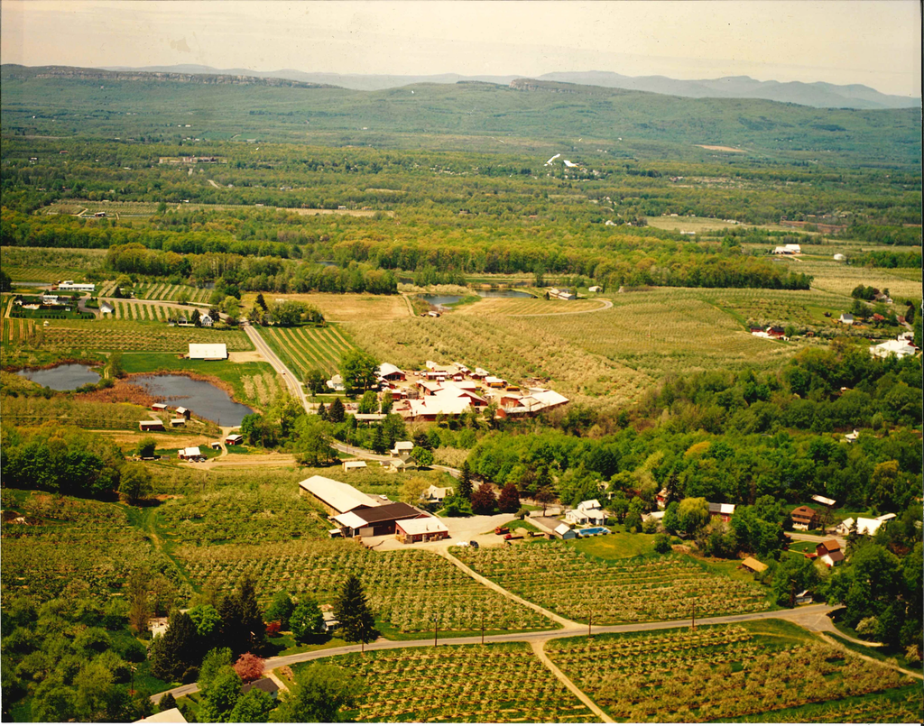

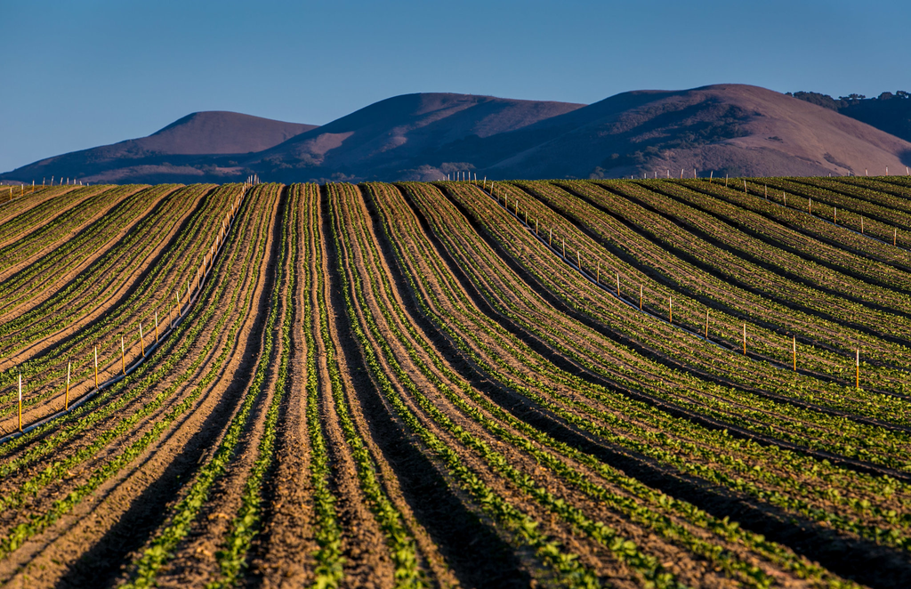

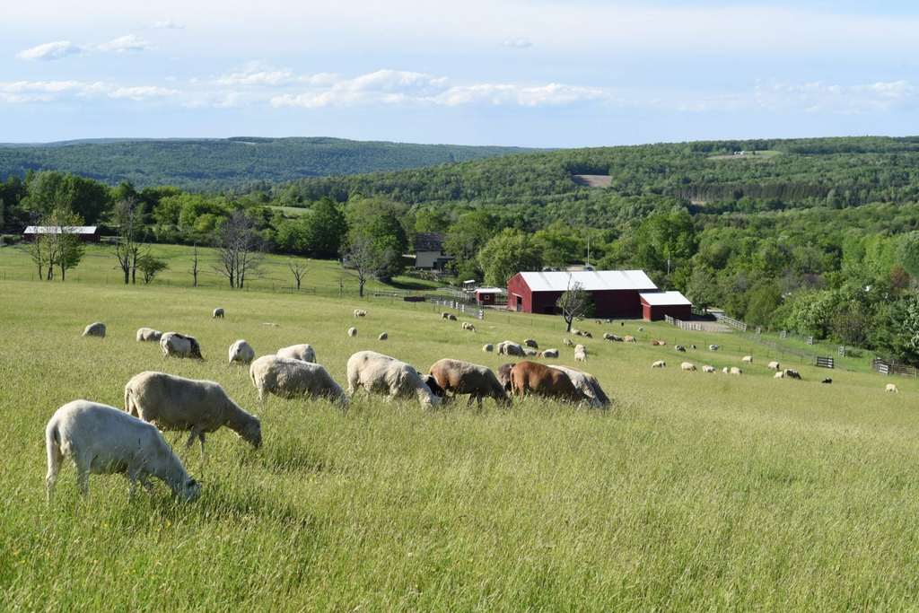

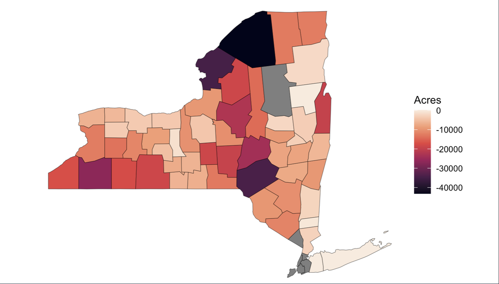

# New York Agriculture: Through the Years

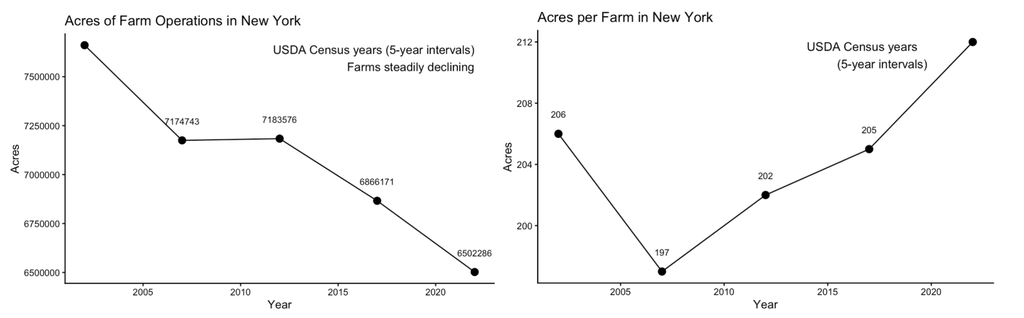

In 2022, while the number of farm operations was at its lowest, acreage per farm was at its peak.

This consolidation seems reflect the shift toward industrial-scale agriculture, with fewer farmers managing more land, concentrating production in fewer hands.

The environmental implications are stark: acres of pastureland have decreased by 46.2% from 2002 to 2022, yet cattle inventory decreased by only 2.3% in the same period.

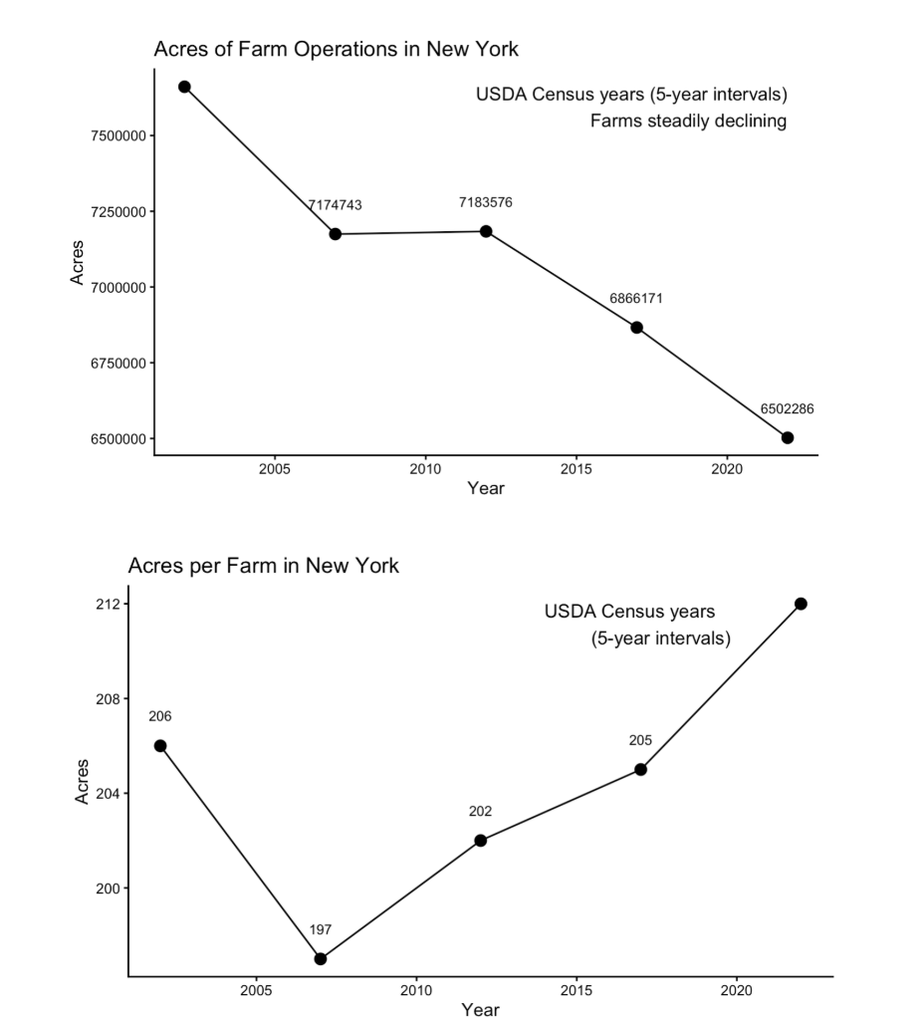

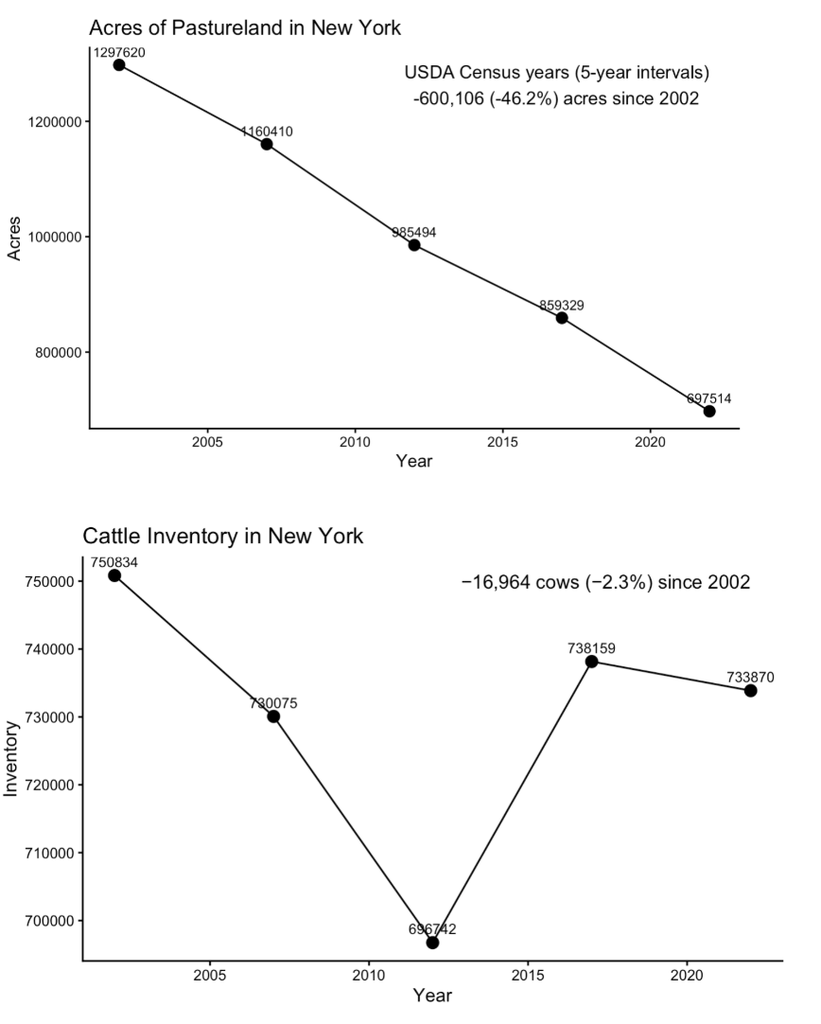

# Note

A lot of things to finetune (need to figure out how to get rid of the grey bar at the top), but this is kind of how it looks. We can also add in code to zoom in and focus on different areas of a graphic, which would be great for map analysis that is completed. I inputted some other aspects of the writeup without any formatting below:

# Objective and Scope

The overarching objective for the New York component of Hoofprint is to map and analyze land use in a way that highlights how much land is devoted to agricultural production, livestock use of pasture, and livestock feed production. Unlike general land-use maps that emphasize urbanization or broad ecological categories, this project focuses on the agricultural landscape and its intersections with pasture, forage, and cropland systems. The maps and analysis herein seek to address the following questions:

- How much of New York’s land area is devoted to agricultural uses, particularly those related to livestock?
- Within agricultural land, how much is devoted to feed production versus crops primarily used for human food or energy use?
- How do patterns of crop production correlate with livestock distribution, especially dairy cattle?
- What aspects of agricultural land use are not easily visible on a map but can be understood through other forms of data analysis or visualization?

# Emerging Findings

## *Agriculture Dominates Actively Managed Land*

Preliminary mapping and quantitative data reveal that a substantial proportion of New York’s actively managed land is agricultural, and much of that is tied to livestock feed production and grazing. Cropland devoted to feed and forage crops, combined with grassland pasture and range, represents a significant share of agricultural acreage.

## *Forage and Feed Crops Are Central*

Cropping patterns show the concentration of silage, hay, and alfalfa, all of which are used exclusively for livestock feed. National and state production data indicate that these crops account for a large share of cropland acreage in the state, particularly in counties with high dairy density.

## *Feed Consumption Reinforces Agricultural Intensity*

While not directly presentable in a map, feed consumption estimates show that New York is a substantial consumer of livestock feed ingredients, especially dairy cattle. This underscores the demand side of animal agriculture and complements the supply side observations from crop and land data, even as we reiterate that consumption figures cannot substitute for maps of what is produced within the state.

## *Land Use Change and Conversion Pressure*

While we don’t directly measure land use change over time in this project, the spatial distribution of cropland, pasture, and forest lands highlights regions where land use transitions are most likely to occur. Prior research and agricultural trends data suggest that pressures from feed crop demand, development, and farm consolidation can drive shifts among pasture, cropland, and non-agricultural uses. According to a 2025 audit by the New York State Comptroller’s Office, USDA Census data shows that NY state lost roughly 365,000 acres of farmland and nearly 2,800 farms between 2017 and 2022, equivalent to an area larger than 430 Central Parks. The audit attributed these changes to financial pressure on farmers, increasing land value, and development pressures, including conversion to residential, commercial, and, in some cases, renewable energy uses such as solar arrays on agricultural land. These loss patterns, while not directly mapped in the current project, provide important context and suggest that land use dynamics in New York are not static, and that pressures on farmland, including feed crop land, may influence future land-use distributions.

## *Carbon Opportunity Costs of Feed Cropland*

Large areas of New York’s cropland are dedicated to feed crops that could otherwise support alternative land uses with greater carbon sequestration potential, such as reforestation, afforestation, or restoration of native grasslands. The concept of carbon opportunity cost (COC) highlights the foregone climate benefits associated with keeping land in high-emission agricultural use instead of allowing it to recover carbon naturally. In regions dominated by feed production for dairy, the COC may represent a substantial but often overlooked component of the livestock system’s total climate footprint.

Our data reveals that substantial areas of New York’s cropland are devoted to feed production, particularly for dairy systems. From a land-use perspective, this raises questions about carbon opportunity costs, or the foregone climate benefits that could accrue if some land was instead allocated to lower-emission or carbon-sequestering uses. While this project does not estimate carbon outcomes directly, it identifies the spatial footprint of cropland used for animal feed as a key input for climate modeling. An interesting article in which they have quantified the hidden “environmental costs” of food – https://www.nytimes.com/interactive/2024/09/19/climate/food-costs-protein-environment.html.

## *Climate Impacts of Land-Intensive Livestock Systems*

New York’s dairy and livestock industries are major contributors to agricultural greenhouse gas emissions, particularly methane from enteric fermentation and manure management, and nitrous oxide from feed production. The spatial concentration of livestock operations, especially in areas with intensive corn silage and hay cultivation, amplifies localized emissions and ties land use directly to climate outcomes. At the same time, emissions from industrial cattle systems remain highly underestimated, due in part to a lack of granular, state-specific data on feed production, sourcing, and use. Insufficient feed data is a critical driver of uncertainty in emissions estimates, compounded by rapid changes in land use, evolving production practices, and limited temporal resolution in available datasets. These data gaps and dynamics contribute to wide variability in emissions modeling results and make it difficult to fully capture the climate impacts of land-intensive livestock systems. More broadly, the contribution of land use and livestock production to global temperature increases remains a significantly under-researched area, underscoring the importance of improved land use mapping and data integration as foundational inputs for climate analysis and accountability.

# Corn Ethanol Visualization

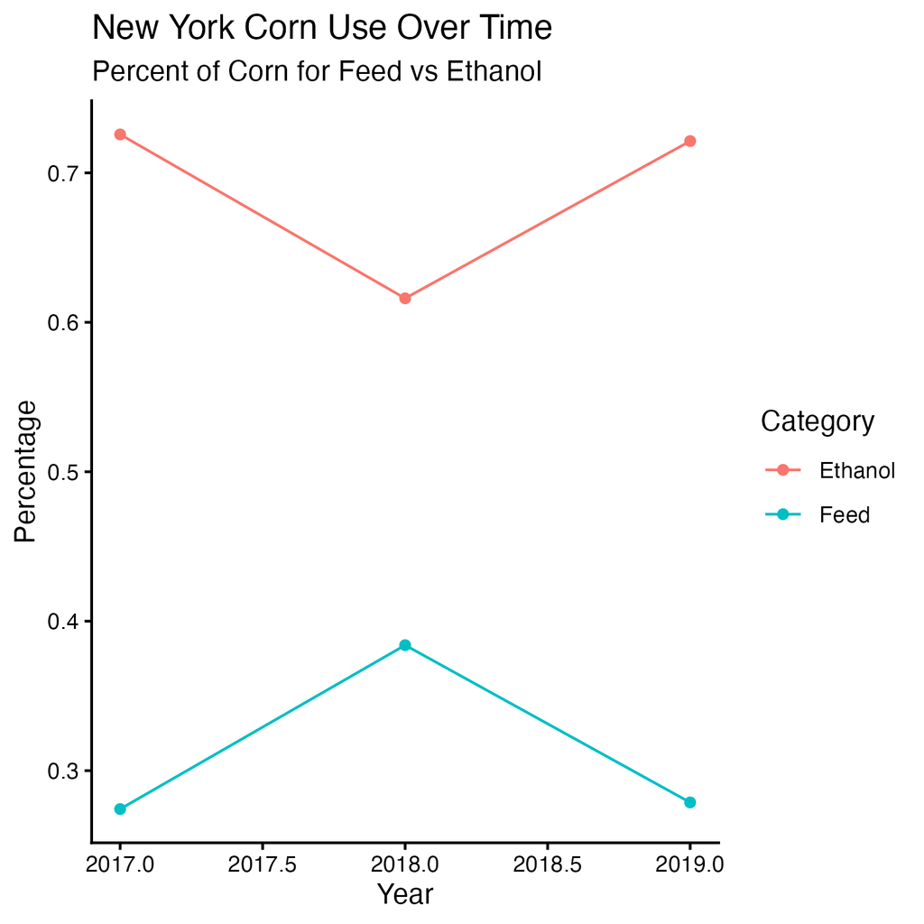

# dairy cattle map

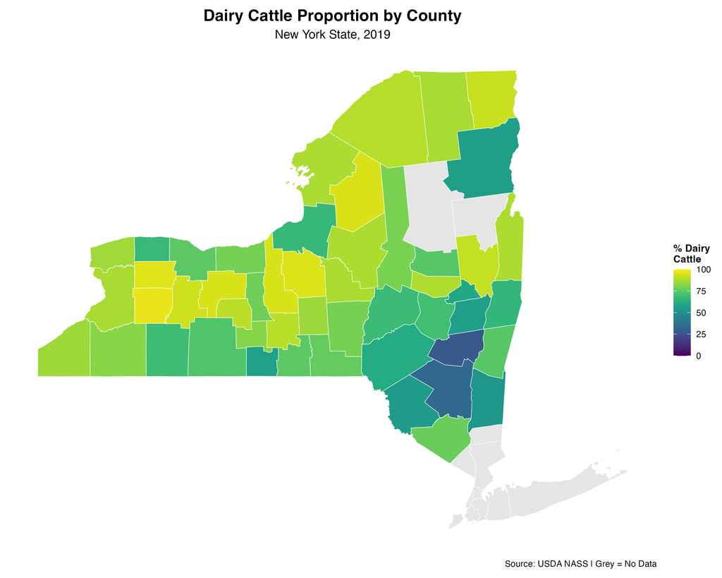